# MA 677 Midterm Project

2024-03-29

## Order statistics - Required

# Uniform Distribution:

For a uniform distribution U(0, 1), the probability density function (pdf) of the i-th order statistic X_(i) is given by the beta distribution with parameters alpha = i and beta = n - i + 1.

# Exponential Distribution:

For an exponential distribution with rate λ, the pdf of the i-th order statistic X_(i) is more complex and involves the Gamma function. However, the minimum value (first order statistic) from an exponential distribution is again an exponential distribution with the same rate λ.

# Normal Distribution:

For a normal distribution, order statistics do not have closed-form expressions for their distributions.However, their expected values can be approximated using the quantiles of the standard normal distribution.

```r
# Define the number of simulations and sample size
n_sim <- 10000
n <- 100

# Uniform distribution simulation
uniform_samples <- matrix(runif(n * n_sim), ncol = n)
uniform_order_stats <- apply(uniform_samples, 1, sort)

# Exponential distribution simulation
lambda <- 1  # Rate parameter
exponential_samples <- matrix(rexp(n * n_sim, rate = lambda), ncol = n)
exponential_order_stats <- apply(exponential_samples, 1, sort)

# Normal distribution simulation
normal_samples <- matrix(rnorm(n * n_sim), ncol = n)
normal_order_stats <- apply(normal_samples, 1, sort)

# Calculate the means of the minimum, 25th, 50th, 75th percentile, and maximum
uniform_results <- colMeans(matrix(uniform_order_stats[,c(1, n/4, n/2, 3*n/4, n)], ncol = 5))
exponential_results <- colMeans(matrix(exponential_order_stats[,c(1, n/4, n/2, 3*n/4, n)], ncol = 5))
normal_results <- colMeans(matrix(normal_order_stats[,c(1, n/4, n/2, 3*n/4, n)], ncol = 5))

# Print the results
print('Uniform distribution order statistics:')
```

```
## [1] "Uniform distribution order statistics:"
```

```r
print(uniform_results)
```

```
## [1] 0.4750537 0.4846313 0.5363903 0.4435420 0.5095575
```

```r
print('Exponential distribution order statistics:')
```

```
## [1] "Exponential distribution order statistics:"
```

```r
print(exponential_results)
```

```
## [1] 0.8595398 1.1506249 0.9918176 0.8773604 1.0899182
```

```r
print('Normal distribution order statistics:')
```

```
## [1] "Normal distribution order statistics:"
```

```r
print(normal_results)
```

```
## [1] -0.08073687  0.08726966 -0.16479476  0.00863416 -0.11460366
```

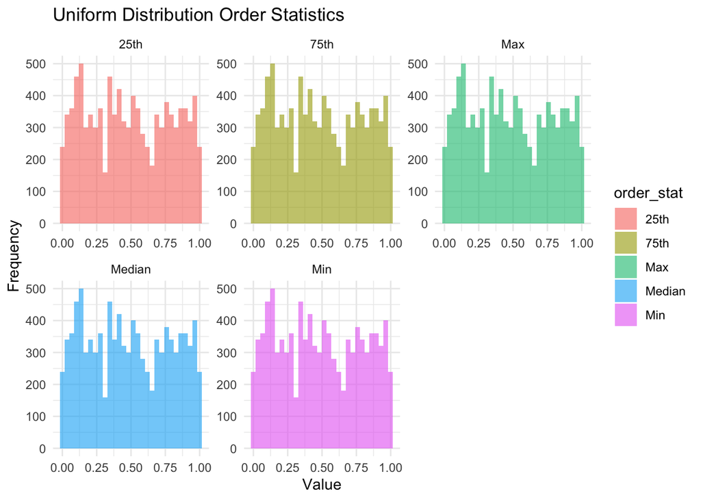

```r
# Load required libraries
library(ggplot2)

# Create data frames for plotting
uniform_data <- data.frame(value = c(uniform_order_stats[,1], uniform_order_stats[,n/4],
                                     uniform_order_stats[,n/2], uniform_order_stats[,3*n/4],
                                     uniform_order_stats[,n]),
                           order_stat = rep(c('Min', '25th', 'Median', '75th', 'Max'), each = n_sim))

exponential_data <- data.frame(value = c(exponential_order_stats[,1], exponential_order_stats[,n/4],
                                         exponential_order_stats[,n/2], exponential_order_stats[,3*n/4],
                                         exponential_order_stats[,n]),
                               order_stat = rep(c('Min', '25th', 'Median', '75th', 'Max'), each = n_sim))

normal_data <- data.frame(value = c(normal_order_stats[,1], normal_order_stats[,n/4],
                                    normal_order_stats[,n/2], normal_order_stats[,3*n/4],
                                    normal_order_stats[,n]),
                          order_stat = rep(c('Min', '25th', 'Median', '75th', 'Max'), each = n_sim))

# Plot for Uniform distribution
ggplot(uniform_data, aes(x=value, fill=order_stat)) +
  geom_histogram(bins=30, alpha=0.6) +
  facet_wrap(~order_stat, scales='free') +
  labs(title='Uniform Distribution Order Statistics', x='Value', y='Frequency') +
  theme_minimal()
```